# facility-assignment-and-routing-problem

## Production and Transportation Scheduling

### Problem Description:

- Assign a given set of orders to plants and carriers to minimize cost.
  - select the appropriate plant that processes the order
  - select the port from which to send the order to its destination
- Restrictions
  - a given plant can only process certain products
  - each plant is only connected to certain ports. (see Supply Chain Mapping below.)
  - some customers have a vendor managed inventory (VMI) which means that they can only be serviced by a certain plant.

## Code Implementation

### Reading in Data and Graphs

### Supply Chain Mapping

#### Non Interactive with Networkx

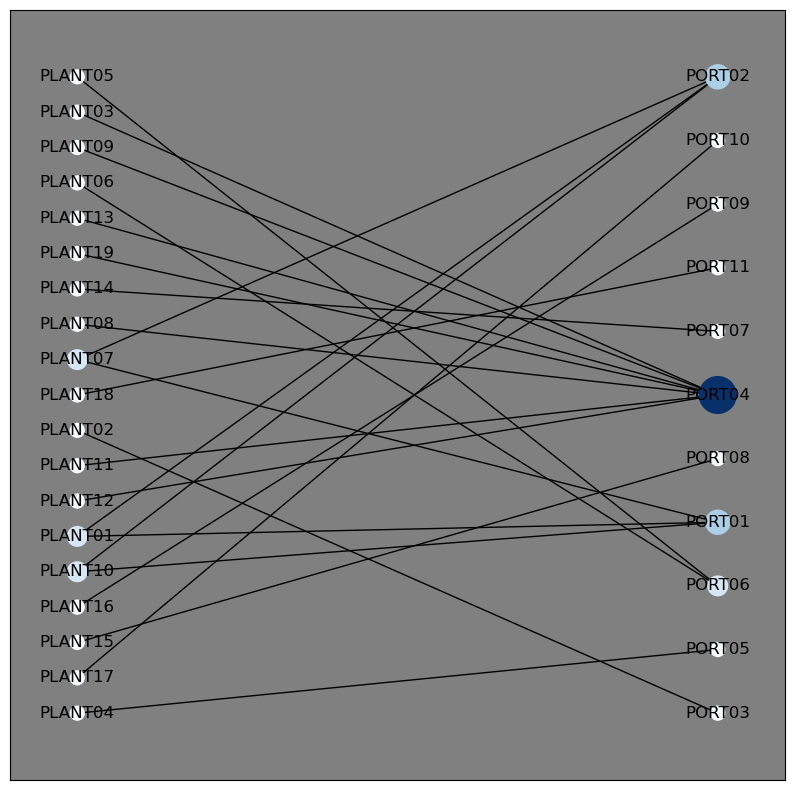

#### Interactive Version with Plotly.

- code adopted from https://plotly.com/python/network-graphs/

Most facilities have only one connection to a port. Port 4 is potentially the most important one as it has the most connections to the warehouses.

### Preparing the Order Table

The existing order table already contains a solution. We will delete those columns.

### Problem Restrictions

```
1    6275
0    1045
4     982
2     785
3     127
5       1
Name: decision_space_size, dtype: int64
```

We can see that for most orders, there is only one facility that can handle the order. For ~1,000 there is no possible facility that can handle the order given our problem restrictions, we will exclude these orders from our further optimization problem.

### Assigning orders

Instead of using the specific rate for a carrier we will aggregate the rates for a given port. The main problem is that rates range from 0.03 to 128 which makes it hard to know the unit of measurement (e.g. €/kg or €/unit). Therefore I will average the rates for each port and use those as the costs.

```
count    1540.000000
mean        2.892656
std         4.603877
min         0.033200
25%         0.470400
50%         1.661200
75%         3.932200
max       128.027200
Name: rate, dtype: float64
```

```
Order_ID
1.447296e+09    (4.7563741745191, PLANT16, 2.8365666666666662,...
1.447158e+09    (4.7563741745191, PLANT16, 2.8365666666666662,...
1.447139e+09    (4.7563741745191, PLANT16, 2.8365666666666662,...
1.447364e+09    (4.7563741745191, PLANT16, 2.8365666666666662,...
1.447364e+09    (4.7563741745191, PLANT16, 2.8365666666666662,...
                                      ...
1.447372e+09    (10.456881296705, PLANT02, 9.979377777777778, ...
1.447372e+09    (10.456881296705, PLANT02, 9.979377777777778, ...
1.447328e+09    (10.456881296705, PLANT02, 9.979377777777778, ...
1.447358e+09    (10.456881296705, PLANT02, 9.979377777777778, ...
1.447287e+09    (10.456881296705, PLANT02, 9.979377777777778, ...
Name: decision, Length: 8170, dtype: object
```

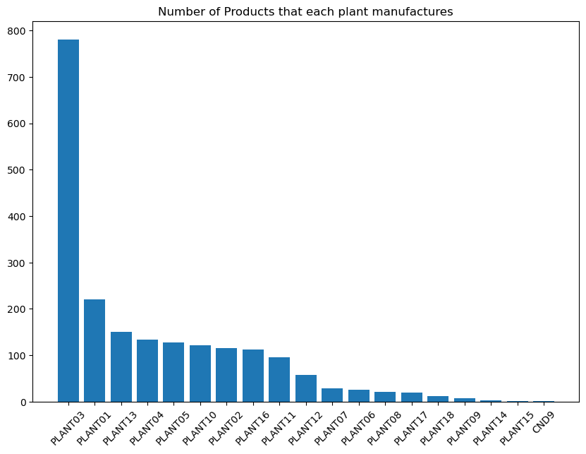

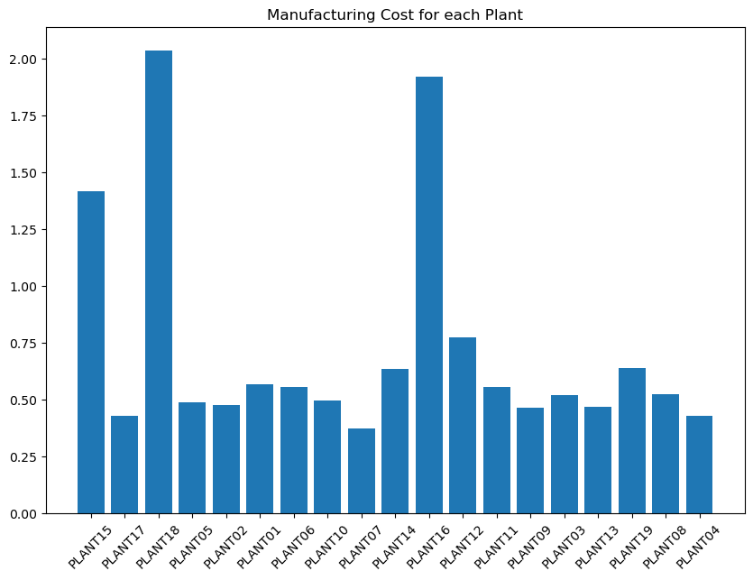